# Financial analysis questions

Karl Polen

May 6, 2019

## Greetings and Instructions

Thank you for applying for the position of Sr. Portfolio Manager – Equities with the Arizona State Retirement. At ASRS we run a quantitative style equities portfolio with enhanced index, factor and alpha overlay components. The person hired for this position will be expected to have very strong quantitative skill sets and the purpose of this exercise is to verify that applicants will be well matched to the requirements of the position.

We have provided sample data in a CSV file called “asset_returns.csv” which was provided in a folder along with this document. The document you are reading has been provided as both an html and a markdown file.

You may respond using whatever analytical platform you are comfortable with. If you use R, Python or another programming language compatible with markdown, you may embed your answers in the markdown document. Please return both the markdown file with code and a compiled HTML version so we can check your answers. If you use Microsoft products, please provide any excel files you produce with adequate documentation. If you want, you can link the results of your analysis to a word or powerpoint presentation.

Make sure your answers are readable and well labeled to avoid any confusion in understanding your work.

You are expected to complete this work on your own. You may consult the internet or other resources for research but may not collaborate through friends, “stack exchange”, social media or otherwise.

There are no trick questions – these are intended to be a test of your ability to complete straight forward applications of standard analytical methods as taught in advanced undergraduate or graduate courses in finance or statistics. Keep it simple.

Questions? Contact Karl Polen at karlp@azasrs.gov

## Background and the Data

The data file contains 60 months of arithmetic returns. Four of the columns are return data for standard assets – Stocks (S&P 500), Bonds (BBG Agg), Commodities (BBG Index) and Cash (90 day Libor). The remaining 3 columns are for mystery portfolios “A”, “B” and “C”. The returns for portfolios A, B and C are reported gross of fees.

The mystery portfolios are represented to be non-correlated to major asset classes. ASRS is considering investing with them in an alpha overlay program (ported over S&P 500). We are going to do some analysis in this exam to help form a view on the project.

## Read in the data and adjust it for fees

Manager “A” charges 200bp per annum in fees, manager “B” charges 30bp and and manager “C” charges 100bp. Read in the data and adjust them for fees assuming they are charged monthly (i.e. 30bp per annum is 2.5bp per month).

## Calculate portfolio weights

Complete the following table of portfolio weights by calculating the minimum variance portfolio and tangency portfolio.

|  | Eq_wgt | Min_var | Tang |
| --- | --- | --- | --- |
| A | 0.3333333 | NA | NA |
| B | 0.3333333 | NA | NA |
| C | 0.3333333 | NA | NA |

For avoidance of doubt and to save you a little time, here are the formulas I want you to use. This is the most vanilla version of how to do this analysis (which, absent any constraints, is closed form and solvable analytically with calculus and linear algebra).

The minimum variance portfolio is calculated with this formula:

$$\frac{\Sigma^{-1} 1}{1'\Sigma^{-1} 1}$$

The relative weights of tangency portfolio are calculated with this formula:

$$\Sigma^{-1} (R_p - R_f)$$

You then normalize those weights to percentages adding to one.

In the foregoing formulas $\Sigma$ is the covariance matrix, $1$ is column vector of ones, $R_p$ is the portfolio expected return and $R_f$ is the risk free rate. Please use the mean return of each portfolio (after deducting fees) as the expected return and the mean value for 90 day Libor as the risk free rate.

```r
ones=as.matrix(c(1,1,1))
covmat=cov(mystery[,-1])
icovmat=solve(covmat)
minport=(icovmat%*%ones)/as.vector(t(ones)%*%icovmat%*%ones)
ervec=apply(mystery[,-1],2,mean)
tanport=as.vector(icovmat%*%(ervec-mean(assets$Cash)))
tanport=tanport/sum(tanport)
wmat$Min_var=minport
wmat$Tang=tanport
kable(wmat)
```

|  | Eq_wgt | Min_var | Tang |
| --- | --- | --- | --- |
| A | 0.3333333 | 0.2712383 | 0.4024554 |
| B | 0.3333333 | 0.5797508 | 0.0065236 |
| C | 0.3333333 | 0.1490108 | 0.5910211 |

## Calculate portfolio statistics

Using the weights derived above calculate portfolio returns for the Equal Weight, Minimum Variance and Tangency portfolios. We now have 60 months of arithmetic returns on 6 portfolios (“A”, “B”, “C”, “Equal Weight”, “Min Variance” and “Tangency”).

Please present summary statistics on each of the portfolios including (at least) mean, median, 1st quartile, 3rd quartile, min, max, standard deviation, skewness, kurtosis.

```r
mystery$Eq_wgt=as.matrix(mystery[,c(2,3,4)])%*%as.matrix(wmat$Eq_wgt)
mystery$Min_var=as.matrix(mystery[,c(2,3,4)])%*%as.matrix(wmat$Min_var)
mystery$Tang=as.matrix(mystery[,c(2,3,4)])%*%as.matrix(wmat$Tang)
basicStats(mystery[,-1])
```

```
##                     A         B         C    Eq_wgt   Min_var      Tang
## nobs        60.000000 60.000000 60.000000 60.000000 60.000000 60.000000
## NAs          0.000000  0.000000  0.000000  0.000000  0.000000  0.000000
## Minimum     -0.068709 -0.046991 -0.062633 -0.039431 -0.027314 -0.055350
## Maximum      0.094953  0.056650  0.061967  0.044295  0.041004  0.058639
## 1. Quartile -0.013468 -0.009219 -0.015333 -0.008987 -0.008934 -0.010059
## 3. Quartile  0.021399  0.013517  0.023692  0.016329  0.015248  0.020244
## Mean         0.005143  0.002251  0.004753  0.004049  0.003408  0.004894
## Median       0.004120 -0.001100  0.001617  0.003011  0.001601  0.005345
## Sum          0.308605  0.135062  0.285200  0.242956  0.204506  0.293640
## SE Mean      0.004207  0.002737  0.003373  0.002344  0.002224  0.002812
## LCL Mean    -0.003275 -0.003227 -0.001995 -0.000642 -0.001041 -0.000732
## UCL Mean     0.013562  0.007729  0.011502  0.008740  0.007858  0.010520
## Variance     0.001062  0.000450  0.000683  0.000330  0.000297  0.000474
## Stdev        0.032589  0.021205  0.026125  0.018160  0.017223  0.021780
## Skewness     0.560662  0.162819 -0.040384 -0.008970  0.099232 -0.109798
## Kurtosis     0.995909 -0.086059 -0.497607 -0.516275 -0.711594 -0.003190
```

## Confidence intervals

Let’s calculate p values that the portfolios will have positive cumulative returns after one and three year periods. (We will assume for now the data are normally distributed – they aren’t and we will examine that later).

First, keep in mind that the statistics we have calculated so far are monthly arithmetic returns and we need to adjust to geometric returns before compounding to multi-period returns. While a number of methods are found to solve this, we will use a simple version (illustrated at William Sharpe’s website (https://web.stanford.edu/~wfsharpe/mia/rr/mia_rr3.htm)

(1+g)^n = ((1+r)^2 - sd^2) ^ (n/2)

Please adjust the monthly volatility for longer periods by multiplying by the square root of the number of months (i.e. the annual volatility is the monthly volatility times the square root of 12).

Create a table calculating the one year and three year p values (i.e. the probability that the cumulative return is less than 0).

```r
p13=function(x) {
  ans=vector()
  ans[1]=pnorm(0,-1+((1+mean(x))^2-sd(x)^2)^6,sd(x)*sqrt(12))
  ans[2]=pnorm(0,-1+((1+mean(x))^2-sd(x)^2)^18,sd(x)*sqrt(36))
  ans
}
pmat=data.frame(lapply(mystery[,-1],p13))
rownames(pmat)=c("Pval_1yr","Pval_3yr")
kable(pmat,digits=2)
```

|  | A | B | C | Eq_wgt | Min_var | Tang |
| --- | --- | --- | --- | --- | --- | --- |
| Pval_1yr | 0.31 | 0.37 | 0.27 | 0.22 | 0.25 | 0.22 |
| Pval_3yr | 0.18 | 0.28 | 0.14 | 0.08 | 0.11 | 0.08 |

## Resampling

Let’s examine the impact of the assumption of normality on our analysis. First, let’s plot the data to visually examine how far off this assumption might be.

Prepare boxplots to demonstrate the comparative dispersion of the data. ( https://en.wikipedia.org/wiki/Box_plot )

```r
mysterylong=gather(mystery,"Portfolio","Return",-Date)
```

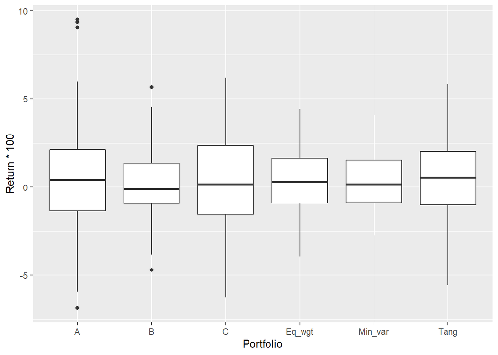

```r
ggplot(mysterylong,aes(x=Portfolio, y=Return*100))+geom_boxplot()
```

Do a density plot comparing the six portfolios. ( https://en.wikipedia.org/wiki/Probability_density_function )

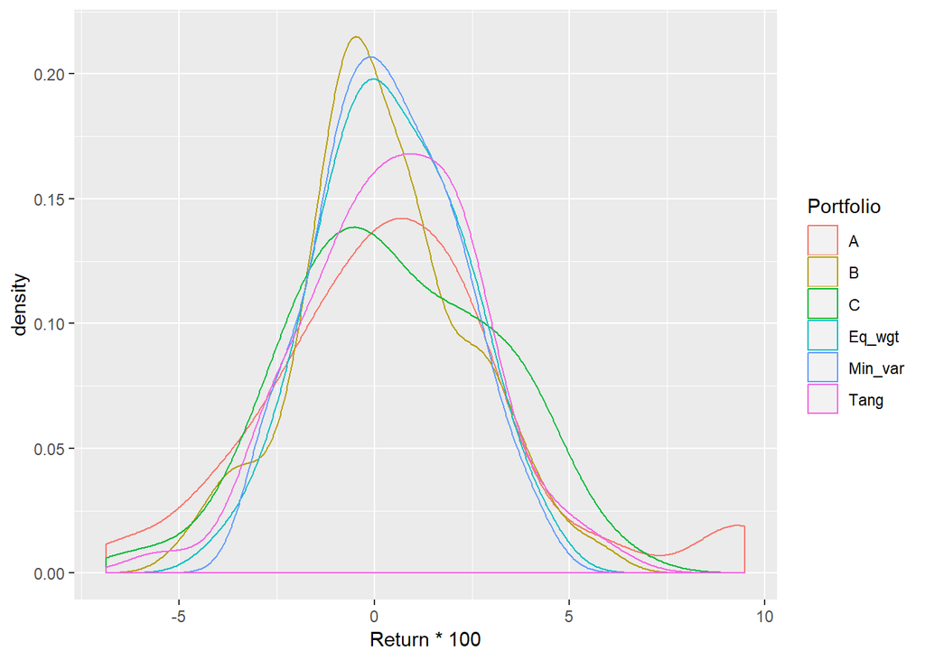

```r
ggplot(mysterylong,aes(x=Return*100,color=Portfolio))+geom_density()
```

You will observe that the portfolios are not normally distributed. I have separately confirmed that there is no significant auto correlation in the data and we can proceed with resampling analysis to gain a better understanding of the dispersion and likelihood that th e portfolios will produce positive outcomes.

Do a bootstrap analysis ( https://en.wikipedia.org/wiki/Bootstrapping_(statistics) ) to recalculate the p values above. (If you are doing this by hand in excel, you can limit this to 100 iterations to keep the file size reasonable.)

```r
pboot13=function(x) {
  yr1vec=yr3vec=ans=vector()
  for(i in 1:1000) {
  s1=x[sample(1:60,12,replace=TRUE)]
  s1ret=-1+prod(1+s1)
  yr1vec[i]=0>s1ret
  s3=x[sample(1:60,36,replace=TRUE)]
  s3ret=-1+prod(1+s3)
  yr3vec[i]=0>s3ret
  }
  ans[1]=sum(yr1vec)/1000
  ans[2]=sum(yr3vec)/1000
  ans
}
pbmat=data.frame(lapply(mystery[,-1],pboot13))
rownames(pbmat)=c("Pval_1yr","Pval_3yr")
kable(pbmat,digits=2)
```

|  | A | B | C | Eq_wgt | Min_var | Tang |
| --- | --- | --- | --- | --- | --- | --- |
| Pval_1yr | 0.3 | 0.38 | 0.30 | 0.23 | 0.27 | 0.23 |
| Pval_3yr | 0.2 | 0.30 | 0.16 | 0.09 | 0.11 | 0.10 |

## Regression analysis

First, let’s do single regression analysis to calculate standard CAPM statistics. Let’s use a market portfolio of 55% stocks, 40% bonds and 5% commodities. We will be regressing the excess return of each portfolio against the excess return in the market portfolio. Display a regression panel that includes t or p values for each regression statistic and an estimate of r-squared.

```r
market=as.matrix(assets[,-1])%*%as.matrix(c(-1,.55,.4,.05))
capm=function(x) {
  ans=lm((x-assets$Cash)~market)
  summary(ans)
}
lapply(mystery[,-1],capm)
```

```
## $A
##
## Call:
## lm(formula = (x - assets$Cash) ~ market)
##
## Residuals:
##       Min        1Q    Median        3Q       Max
## -0.083070 -0.017598 -0.000492  0.015937  0.086828
##
## Coefficients:
##              Estimate Std. Error t value Pr(>|t|)
## (Intercept)  0.005393   0.004331   1.245    0.218
## market      -0.252038   0.228273  -1.104    0.274
##
## Residual standard error: 0.03251 on 58 degrees of freedom
## Multiple R-squared:  0.02059,    Adjusted R-squared:  0.003699
## F-statistic: 1.219 on 1 and 58 DF,  p-value: 0.2741
##
##
## $B
##
## Call:
## lm(formula = (x - assets$Cash) ~ market)
##
## Residuals:
##       Min        1Q    Median        3Q       Max
## -0.051736 -0.011513 -0.002886  0.008388  0.057622
##
## Coefficients:
##              Estimate Std. Error t value Pr(>|t|)
## (Intercept) 0.0006389  0.0028508   0.224    0.823
## market      0.1460479  0.1502463   0.972    0.335
##
## Residual standard error: 0.0214 on 58 degrees of freedom
## Multiple R-squared:  0.01603,    Adjusted R-squared:  -0.0009349
## F-statistic: 0.9449 on 1 and 58 DF,  p-value: 0.3351
##
##
## $C
##
```

[output cut: 59 more lines]

```
## Call:
## lm(formula = (x - assets$Cash) ~ market)
##
## Residuals:
##       Min        1Q    Median        3Q       Max
## -0.054173 -0.014442 -0.000356  0.015599  0.056494
##
## Coefficients:
##             Estimate Std. Error t value Pr(>|t|)
## (Intercept) 0.003318   0.002914   1.139    0.260
## market      0.138260   0.153584   0.900    0.372
##
## Residual standard error: 0.02188 on 58 degrees of freedom
## Multiple R-squared:  0.01378,    Adjusted R-squared:  -0.003224
## F-statistic: 0.8104 on 1 and 58 DF,  p-value: 0.3717
```

Finally, we will do multiple regression to determine the regression coefficients (i.e. the “betas”) relative to the asset classes of cash, stocks, bonds and commodities).

```r
multi=function(x) {
  ans=lm(x~assets$Cash+assets$Stocks+assets$Bonds+assets$Commodities)
  summary(ans)
}
lapply(mystery[,-1],multi)
```

```
## $A
##
## Call:
## lm(formula = x ~ assets$Cash + assets$Stocks + assets$Bonds +
##     assets$Commodities)
##
## Residuals:
##       Min        1Q    Median        3Q       Max
## -0.077547 -0.014103 -0.001408  0.014583  0.086422
##
## Coefficients:
##                     Estimate Std. Error t value Pr(>|t|)
## (Intercept)         0.002202   0.007635   0.288    0.774
## assets$Cash         2.772758   6.125182   0.453    0.653
## assets$Stocks      -0.069442   0.142196  -0.488    0.627
## assets$Bonds       -0.091126   0.523314  -0.174    0.862
## assets$Commodities -0.169283   0.135371  -1.251    0.216
##
## Residual standard error: 0.03298 on 55 degrees of freedom
## Multiple R-squared:  0.04508,    Adjusted R-squared:  -0.02437
## F-statistic: 0.6491 on 4 and 55 DF,  p-value: 0.6299
##
##
## $B
##
## Call:
## lm(formula = x ~ assets$Cash + assets$Stocks + assets$Bonds +
##     assets$Commodities)
##
## Residuals:
##       Min        1Q    Median        3Q       Max
## -0.044969 -0.011618  0.000755  0.012318  0.048396
##
## Coefficients:
##                     Estimate Std. Error t value Pr(>|t|)
## (Intercept)         0.005058   0.004682   1.080   0.2847
## assets$Cash        -6.346422   3.755944  -1.690   0.0967 .
## assets$Stocks       0.108357   0.087194   1.243   0.2192
## assets$Bonds        0.577259   0.320895   1.799   0.0775 .
## assets$Commodities -0.108051   0.083009  -1.302   0.1985
```

[output cut: 91 more lines]

```
## -0.049571 -0.013883  0.002297  0.014775  0.052837
##
## Coefficients:
##                     Estimate Std. Error t value Pr(>|t|)
## (Intercept)         0.001585   0.004787   0.331   0.7418
## assets$Cash        -0.756158   3.840341  -0.197   0.8446
## assets$Stocks       0.124607   0.089154   1.398   0.1678
## assets$Bonds        0.758392   0.328105   2.311   0.0246 *
## assets$Commodities -0.158066   0.084874  -1.862   0.0679 .
## ---
## Signif. codes:  0 '***' 0.001 '**' 0.01 '*' 0.05 '.' 0.1 ' ' 1
##
## Residual standard error: 0.02068 on 55 degrees of freedom
## Multiple R-squared:  0.1596, Adjusted R-squared:  0.0985
## F-statistic: 2.612 on 4 and 55 DF,  p-value: 0.04515
```

## Commentary

Write a few paragraphs with your observations based on this analysis.

It seems to that the interesting portfolios are either “A” on its own or the tangency portfolio which is a combination of “A” and “C”.

I like “A” because of its right skewness and because in the simple CAPM analysis it may be a bit negatively correlated to the market (though not statistically significant).

It’s interesting how much risk benefit you get by combining “C” with “A”. “C” on its own is not immediately attractive. When you look at the density function, it’s maximum likelihood is below zero and under simple regression it has a statistically significant positive beta to a market portfolio. But when you combine it with “A”, you have a portfolio that has 90% chance of positive returns after 3 years which much better than either portfolio on its own.

It’s also interesting that the minvol portfolio has little attraction. The return penalty is too high for the risk reduction. On a resampling analysis, you have a higher probability of losing money than you would have with the tangency portfolio.

Reviewing the regression analysis, the r-squareds are low for portfolios “A” and “B”. They seem to have low market correlation, as advertised. As noted above, portfolio “C” has market correlation with statistically significant .26 beta to stocks and 1.34 beta to bonds.

Based on data presented, the case for investing in these strategies is weak with significant risk of disappointment. If you were to proceed, “A” alone (for its high return, low correlation and possible negative market beta) or a combination of “A” and “C” (for its risk mitigation compared to “A” alone) would be your better choices.